# Automatización Web I

Banco de España y evidencia de auditoría

## La investigación de auditoría

CASO SINTÉTICO AUD-2026-017

Varias llamadas sospechosas podrían formar parte de una campaña de suplantación bancaria.

El equipo investiga qué ocurrió y qué controles debían detectarlo. Empezamos reuniendo información pública que pueda orientar las preguntas.

Una publicación pública aporta contexto. Para demostrar qué conocía la entidad necesitaremos además evidencia interna.

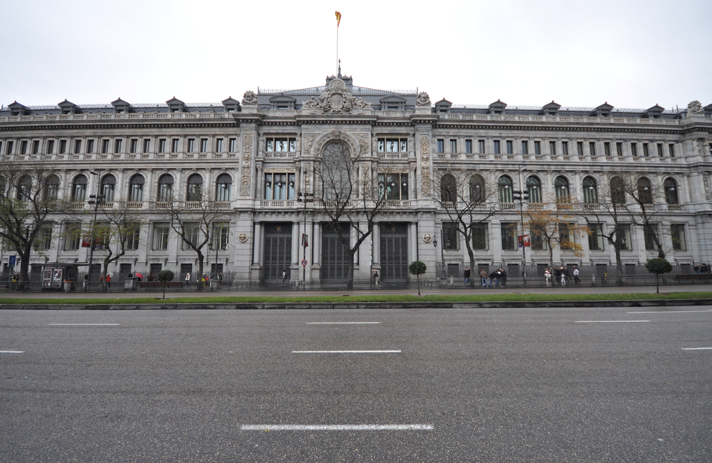

Luis García, Wikimedia Commons. CC BY-SA 2.0. Enlace completo en fuentes.

## El resultado de esta sesión

AUTOMATIZACIÓN WEB I · 60 MINUTOS

> Un JSON con publicaciones del Banco de España, su fecha y la procedencia de la extracción.

Partimos de la introducción al scraping impartida previamente y aplicamos sus conceptos a una fuente real.

**Contenido**

Fecha publicada, título y URL absoluta.

**Procedencia**

Fuente y momento de recogida.

**Integridad**

SHA-256 de la copia utilizada.

**Continuidad**

La sesión II añadirá histórico y detección de cambios.

## Inspección del documento

[figure not shown]

Chrome for Developers. CC BY 4.0. Captura ilustrativa del inspector.

RECORDATORIO APLICADO

El contenedor repetido determina qué consideramos un registro.

Inspeccionamos fecha, título y enlace. Probamos el selector con varios registros y comprobamos si el contenido llega en el HTML o requiere JavaScript.

HTTP transporta la respuesta. BeautifulSoup analiza el HTML recibido. El DOM del navegador puede incluir cambios posteriores de JavaScript.

## Petición HTTP y contenido dinámico

RESPUESTA DEL SERVIDOR

requests recibe bytes, cabeceras y un estado HTTP.

Un 200 indica éxito de la petición, pero podría devolver una página de acceso, un aviso o una estructura inesperada.

BeautifulSoup analiza el HTML recibido y permite recorrer sus nodos.

PÁGINA DEL NAVEGADOR

JavaScript puede modificar el DOM después de recibir el HTML.

Si los registros no llegan en la respuesta inicial, un selector correcto en el inspector puede devolver cero resultados en Python.

Primero comprobamos descargas o APIs oficiales. La automatización del navegador se decide según la fuente.

## Selectores y unidad de observación

> Una publicación es nuestra unidad de observación. Cada fila conserva sus campos y su enlace.

Buscamos fecha y título dentro del mismo contenedor para evitar combinar datos de publicaciones distintas.

**Etiqueta**

`article` selecciona elementos por su nombre.

**Clase**

`.publication` selecciona una clase CSS.

**Descendiente**

`.publication-title a` encuentra un enlace dentro del título.

**Atributo**

`a[href]` exige que el enlace tenga destino.

## Selectores del Banco de España

La muestra reúne metadatos reales en un índice HTML docente. Sus clases CSS son propias.

```html
<article class="publication">
  <time class="publication-date">24/03/2020</time>
  <h2 class="publication-title">
    <a href="/pcb/es/blog/vishing.html">
      Vishing: llamada telefónica no deseada
    </a>
  </h2>
</article>
```

El parser recorre cada contenedor y busca sus campos dentro de él.

Los enlaces relativos necesitan una URL base. Las fechas se convierten a un tipo definido.

Este índice facilita el aprendizaje. El acceso remoto posterior inspecciona un artículo real con otra estructura.

## Contrato de los registros

```python
class PublicAlert(BaseModel):
    published_date: date
    title: str
    url: HttpUrl
    source_id: str
    collected_at: datetime
```

Pydantic valida fechas, URLs y campos obligatorios.

Un registro incompleto o una extracción vacía debe producir un error visible.

La validación del formato no demuestra que el contenido sea verdadero ni que resulte relevante para el caso.

## Calidad, completitud y relevancia

FORMATO**¿Es válido?**

La fecha se interpreta, la URL tiene un formato válido y los campos cumplen el contrato.

Pydantic hace visibles estos errores.

EXTRACCIÓN**¿Falta algo?**

Revisamos campos ausentes, duplicados y registros esperados. Una extracción parcial puede contener filas perfectamente válidas.

INVESTIGACIÓN**¿Responde a la pregunta?**

Un título con “llamada” puede orientar la búsqueda. La relevancia para un hallazgo exige revisar el contexto y contrastar evidencia.

## Procedencia y límites de un hash

PROCEDENCIA

Conservamos qué fuente usamos y qué transformación aplicamos.

Distinguimos fecha publicada, fecha de recopilación y creación del artefacto.

Una selección docente necesita identificar su carácter no exhaustivo.

SHA-256

El hash permite comparar una secuencia de bytes con una referencia.

Un cambio de bytes, incluso de espacios en el HTML, cambia el hash con probabilidad abrumadora.

El hash por sí solo no acredita autoría, veracidad ni fecha. Necesita acompañarse de procedencia.

## Acceso responsable a la fuente

ANTES DE CONSULTAR

Revisamos aviso legal, términos de uso, robots.txt y alternativas oficiales como APIs o descargas.

Definimos el alcance y evitamos datos personales o contenido restringido.

DURANTE LA CONSULTA

Identificamos el agente, limitamos la frecuencia y usamos tiempos de espera.

Una respuesta 200 exige comprobar también el contenido. robots.txt expresa preferencias de rastreo y no concede autorización legal.

## Parte común en el notebook

ORIGEN**Copia local**

Leemos el HTML y calculamos su SHA-256. La copia permite repetir la práctica sin depender de cambios externos.

EXTRACCIÓN**Parser y contrato**

Extraemos los registros, normalizamos enlaces y fechas y validamos la salida.

ARTEFACTO**JSON trazable**

Guardamos las publicaciones y sus metadatos. El acceso remoto queda disponible mediante activación deliberada.

Notebook: `12_web_scraping_para_auditoria.ipynb`

## Exploración visual de las publicaciones

NUEVE ARTÍCULOS OFICIALES

Buscamos “vishing” o “llamada”, cambiamos el intervalo y seguimos un registro desde su HTML hasta el JSON.

Una demostración introduce campos ausentes, selectores rotos y duplicados para observar sus efectos.

LECTURA DEL RESULTADO

El índice combina artículos de distintos años. Su distribución depende de nuestra selección docente.

Una coincidencia de palabras orienta la revisión y conserva la regla que la produjo.

## Ejercicio A o ejercicio B

A · DATOS COMUNES

Priorizar publicaciones con reglas transparentes.

Usamos palabras clave para asignar categorías, conservamos los metadatos y explicamos posibles errores de clasificación.

Dificultad media-baja.

B · FUENTE PROPIA

Adaptar el proceso a una URL elegida.

Justificamos su uso, diseñamos selectores y producimos el mismo contrato, con detección de campos ausentes y duplicados.

Dificultad alta. Se permite trabajar con IA.

## Continuidad del expediente

La siguiente sesión repetirá la recogida y conservará el histórico de cambios.

PublicacionesLlamadasCorreosControles internos

Gradio reunirá estas evidencias en una interfaz de revisión. Los agentes y el RAG añadirán herramientas y procedimientos citados al expediente.

## Fuentes y atribuciones

- [Portal del Cliente Bancario: protección frente al fraude](https://clientebancario.bde.es/pcb/es/menu-horizontal/actualidadeducac/educacion-financiera/protegete-contra-el-fraude/)
- [Artículo sobre vishing](https://clientebancario.bde.es/pcb/es/blog/vishing.html), fechas y enlaces de cada publicación en el notebook
- [Aviso legal del Banco de España](https://www.bde.es/wbe/es/pie/aviso-legal/)
- [RFC 9309: Robots Exclusion Protocol](https://www.rfc-editor.org/rfc/rfc9309.html)
- [Chrome DevTools](https://developer.chrome.com/docs/devtools/), captura bajo CC BY 4.0
- Banco de España, fotografía de Luis García, CC BY-SA 2.0